# **LOAN DEFAULT PREDICTION: A BINARY CLASSIFICATION APPROACH**

```python
# Compute correlation matrix (TRAIN ONLY)
corr = Xtr.corr().abs()  # absolute value for easy thresholding

# Only keep upper triangle to avoid duplicates
upper = corr.where(np.triu(np.ones(corr.shape), k=1).astype(bool))

# Define a function to highlight high correlations
def highlight_high(val):
    if val > 0.85:
        return 'font-weight: bold; color: red'
    else:
        return ''

# Apply styling
styled_corr = upper.style.applymap(highlight_high).format("{:.6f}")

# Display
styled_corr
```

|  | loan_limit | approv_in_adv | Credit_Worthiness | open_credit | business_or_commercial | loan_amount | rate_of_interest | Interest_rate_spread | Upfront_charges | term | Neg_ammortization | interest_only | lump_sum_payment | property_value | income | Credit_Score | co_applicant_credit_type | submission_of_application | LTV | Security_Type | dtir1 | loan_type_type2 | loan_type_type3 | loan_purpose_p2 | loan_purpose_p3 | loan_purpose_p4 | occupancy_type_pr | occupancy_type_sr | Region_north | … |
| --- | --- | --- | --- | --- | --- | --- | --- | --- | --- | --- | --- | --- | --- | --- | --- | --- | --- | --- | --- | --- | --- | --- | --- | --- | --- | --- | --- | --- | --- | --- |
| loan_limit | nan | 0.101713 | 0.021164 | 0.018698 | 0.032404 | 0.281956 | 0.042103 | 0.043013 | 0.037780 | 0.019565 | 0.005070 | 0.027804 | 0.020313 | 0.192868 | 0.144544 | 0.000434 | 0.037143 | 0.009709 | 0.011633 | 0.004123 | 0.000381 | 0.032404 | 0.062503 | 0.005324 | 0.016302 | 0.014379 | 0.008900 | 0.006181 | 0.001102 | … |
| approv_in_adv | nan | nan | 0.061983 | 0.004171 | 0.009656 | 0.029487 | 0.056317 | 0.056563 | 0.019702 | 0.023830 | 0.076580 | 0.073723 | 0.061264 | 0.049196 | 0.010878 | 0.001119 | 0.010744 | 0.081081 | 0.027482 | 0.002084 | 0.006230 | 0.009656 | 0.010185 | 0.010986 | 0.043248 | 0.086134 | 0.011167 | 0.022154 | 0.009050 | … |
| Credit_Worthiness | nan | nan | nan | 0.229926 | 0.004218 | 0.012878 | 0.123121 | 0.047496 | 0.010018 | 0.021060 | 0.058177 | 0.053070 | 0.031597 | 0.024383 | 0.015896 | 0.001762 | 0.012423 | 0.021901 | 0.011294 | 0.004892 | 0.010660 | 0.004218 | 0.013529 | 0.007107 | 0.027172 | 0.050213 | 0.005816 | 0.005561 | 0.003274 | … |
| open_credit | nan | nan | nan | nan | 0.024610 | 0.042321 | 0.173410 | 0.061111 | 0.003066 | 0.025377 | 0.001030 | 0.277790 | 0.005682 | 0.129603 | 0.046696 | 0.003074 | 0.016450 | 0.045454 | 0.072632 | 0.000945 | 0.013714 | 0.024610 | 0.020426 | 0.048608 | 0.060290 | 0.046989 | 0.013033 | 0.002185 | 0.005481 | … |
| business_or_commercial | nan | nan | nan | nan | nan | 0.160213 | 0.076206 | 0.454999 | 0.190514 | 0.093128 | 0.010633 | 0.005409 | 0.016167 | 0.221513 | 0.155160 | 0.001102 | 0.024888 | 0.088969 | 0.133080 | 0.009735 | 0.203786 | 1.000000 | 0.133796 | 0.003318 | 0.031870 | 0.062696 | 0.109930 | 0.058434 | 0.003640 | … |
| loan_amount | nan | nan | nan | nan | nan | nan | 0.116952 | 0.334330 | 0.068491 | 0.175649 | 0.027875 | 0.003185 | 0.001938 | 0.691574 | 0.446687 | 0.004740 | 0.149483 | 0.428007 | 0.032450 | 0.011295 | 0.014795 | 0.160213 | 0.016572 | 0.107630 | 0.155186 | 0.167341 | 0.039966 | 0.035536 | 0.003754 | … |
| rate_of_interest | nan | nan | nan | nan | nan | nan | nan | 0.593952 | 0.054737 | 0.171526 | 0.132274 | 0.006612 | 0.020517 | 0.088417 | 0.003897 | 0.000843 | 0.046302 | 0.120994 | 0.013054 | 0.001228 | 0.006123 | 0.076206 | 0.283050 | 0.151329 | 0.178077 | 0.351457 | 0.198962 | 0.032158 | 0.018067 | … |
| Interest_rate_spread | nan | nan | nan | nan | nan | nan | nan | nan | 0.004417 | 0.123961 | 0.030712 | 0.002632 | 0.004693 | 0.302250 | 0.123692 | 0.001346 | 0.075528 | 0.286515 | 0.040226 | 0.004940 | 0.052856 | 0.454999 | 0.367992 | 0.152490 | 0.230811 | 0.335859 | 0.109989 | 0.008028 | 0.006240 | … |
| Upfront_charges | nan | nan | nan | nan | nan | nan | nan | nan | nan | 0.050899 | 0.032006 | 0.007283 | 0.024467 | 0.062219 | 0.043261 | 0.001684 | 0.005629 | 0.272319 | 0.038706 | 0.004642 | 0.038945 | 0.190514 | 0.058536 | 0.012791 | 0.201621 | 0.124964 | 0.034644 | 0.007861 | 0.071772 | … |
| term | nan | nan | nan | nan | nan | nan | nan | nan | nan | nan | 0.023399 | 0.012989 | 0.010805 | 0.042064 | 0.056997 | 0.002335 | 0.007095 | 0.153928 | 0.093746 | 0.000765 | 0.115116 | 0.093128 | 0.084007 | 0.028553 | 0.076713 | 0.042458 | 0.009372 | 0.019168 | 0.032763 | … |
| Neg_ammortization | nan | nan | nan | nan | nan | nan | nan | nan | nan | nan | nan | 0.022010 | 0.051513 | 0.029537 | 0.001920 | 0.001094 | 0.009377 | 0.051519 | 0.008079 | 0.009405 | 0.015706 | 0.010633 | 0.015115 | 0.018184 | 0.017625 | 0.065172 | 0.032516 | 0.014528 | 0.000008 | … |
| interest_only | nan | nan | nan | nan | nan | nan | nan | nan | nan | nan | nan | nan | 0.032740 | 0.050945 | 0.014066 | 0.001680 | 0.014633 | 0.012668 | 0.021831 | 0.000785 | 0.005334 | 0.005409 | 0.008436 | 0.005957 | 0.006457 | 0.008711 | 0.009151 | 0.000347 | 0.002814 | … |
| lump_sum_payment | nan | nan | nan | nan | nan | nan | nan | nan | nan | nan | nan | nan | nan | 0.012496 | 0.008969 | 0.003294 | 0.034818 | 0.012957 | 0.007444 | 0.008668 | 0.010133 | 0.016167 | 0.000050 | 0.006767 | 0.011943 | 0.015508 | 0.003594 | 0.000686 | 0.015183 | … |
| property_value | nan | nan | nan | nan | nan | nan | nan | nan | nan | nan | nan | nan | nan | nan | 0.397836 | 0.002054 | 0.108297 | 0.295206 | 0.199686 | 0.010299 | 0.067572 | 0.221513 | 0.072979 | 0.001276 | 0.032677 | 0.136221 | 0.007163 | 0.028057 | 0.013973 | … |
| income | nan | nan | nan | nan | nan | nan | nan | nan | nan | nan | nan | nan | nan | nan | nan | 0.001603 | 0.144702 | 0.176579 | 0.037461 | 0.006632 | 0.265633 | 0.155160 | 0.075167 | 0.004654 | 0.105194 | 0.063256 | 0.195874 | 0.133053 | 0.006413 | … |
| Credit_Score | nan | nan | nan | nan | nan | nan | nan | nan | nan | nan | nan | nan | nan | nan | nan | nan | 0.002157 | 0.001033 | 0.005387 | 0.000433 | 0.000047 | 0.001102 | 0.004256 | 0.000495 | 0.001824 | 0.001193 | 0.006412 | 0.001023 | 0.000304 | … |
| co_applicant_credit_type | nan | nan | nan | nan | nan | nan | nan | nan | nan | nan | nan | nan | nan | nan | nan | nan | nan | 0.064113 | 0.006524 | 0.007662 | 0.023512 | 0.024888 | 0.045676 | 0.023149 | 0.037289 | 0.024410 | 0.017653 | 0.027335 | 0.002342 | … |
| submission_of_application | nan | nan | nan | nan | nan | nan | nan | nan | nan | nan | nan | nan | nan | nan | nan | nan | nan | nan | 0.020672 | 0.003377 | 0.012200 | 0.088969 | 0.051818 | 0.042164 | 0.255293 | 0.171424 | 0.050053 | 0.010405 | 0.138372 | … |
| LTV | nan | nan | nan | nan | nan | nan | nan | nan | nan | nan | nan | nan | nan | nan | nan | nan | nan | nan | nan | 0.002665 | 0.081400 | 0.133080 | 0.091259 | 0.077558 | 0.097586 | 0.000569 | 0.047425 | 0.003814 | 0.012230 | … |
| Security_Type | nan | nan | nan | nan | nan | nan | nan | nan | nan | nan | nan | nan | nan | nan | nan | nan | nan | nan | nan | nan | 0.003694 | 0.009735 | 0.000370 | 0.005195 | 0.002878 | 0.003837 | 0.004236 | 0.002257 | 0.005382 | … |
| dtir1 | nan | nan | nan | nan | nan | nan | nan | nan | nan | nan | nan | nan | nan | nan | nan | nan | nan | nan | nan | nan | nan | 0.203786 | 0.116676 | 0.029034 | 0.021600 | 0.045850 | 0.027970 | 0.027641 | 0.025913 | … |
| loan_type_type2 | nan | nan | nan | nan | nan | nan | nan | nan | nan | nan | nan | nan | nan | nan | nan | nan | nan | nan | nan | nan | nan | nan | 0.133796 | 0.003318 | 0.031870 | 0.062696 | 0.109930 | 0.058434 | 0.003640 | … |
| loan_type_type3 | nan | nan | nan | nan | nan | nan | nan | nan | nan | nan | nan | nan | nan | nan | nan | nan | nan | nan | nan | nan | nan | nan | nan | 0.048630 | 0.023578 | 0.032825 | 0.091560 | 0.048784 | 0.007506 | … |
| loan_purpose_p2 | nan | nan | nan | nan | nan | nan | nan | nan | nan | nan | nan | nan | nan | nan | nan | nan | nan | nan | nan | nan | nan | nan | nan | nan | 0.116458 | 0.114978 | 0.114848 | 0.024069 | 0.000287 | … |
| loan_purpose_p3 | nan | nan | nan | nan | nan | nan | nan | nan | nan | nan | nan | nan | nan | nan | nan | nan | nan | nan | nan | nan | nan | nan | nan | nan | nan | 0.595251 | 0.054295 | 0.081030 | 0.032844 | … |
| loan_purpose_p4 | nan | nan | nan | nan | nan | nan | nan | nan | nan | nan | nan | nan | nan | nan | nan | nan | nan | nan | nan | nan | nan | nan | nan | nan | nan | nan | 0.058016 | 0.038023 | 0.031638 | … |
| occupancy_type_pr | nan | nan | nan | nan | nan | nan | nan | nan | nan | nan | nan | nan | nan | nan | nan | nan | nan | nan | nan | nan | nan | nan | nan | nan | nan | nan | nan | 0.532810 | 0.021825 | … |
| occupancy_type_sr | nan | nan | nan | nan | nan | nan | nan | nan | nan | nan | nan | nan | nan | nan | nan | nan | nan | nan | nan | nan | nan | nan | nan | nan | nan | nan | nan | nan | 0.020491 | … |
| Region_north | nan | nan | nan | nan | nan | nan | nan | nan | nan | nan | nan | nan | nan | nan | nan | nan | nan | nan | nan | nan | nan | nan | nan | nan | nan | nan | nan | nan | nan | … |
| Region_north-east | nan | nan | nan | nan | nan | nan | nan | nan | nan | nan | nan | nan | nan | nan | nan | nan | nan | nan | nan | nan | nan | nan | nan | nan | nan | nan | nan | nan | nan | … |
| Region_south | nan | nan | nan | nan | nan | nan | nan | nan | nan | nan | nan | nan | nan | nan | nan | nan | nan | nan | nan | nan | nan | nan | nan | nan | nan | nan | nan | nan | nan | … |
| credit_type_crif | nan | nan | nan | nan | nan | nan | nan | nan | nan | nan | nan | nan | nan | nan | nan | nan | nan | nan | nan | nan | nan | nan | nan | nan | nan | nan | nan | nan | nan | … |
| credit_type_equi | nan | nan | nan | nan | nan | nan | nan | nan | nan | nan | nan | nan | nan | nan | nan | nan | nan | nan | nan | nan | nan | nan | nan | nan | nan | nan | nan | nan | nan | … |
| credit_type_exp | nan | nan | nan | nan | nan | nan | nan | nan | nan | nan | nan | nan | nan | nan | nan | nan | nan | nan | nan | nan | nan | nan | nan | nan | nan | nan | nan | nan | nan | … |
| Gender_joint | nan | nan | nan | nan | nan | nan | nan | nan | nan | nan | nan | nan | nan | nan | nan | nan | nan | nan | nan | nan | nan | nan | nan | nan | nan | nan | nan | nan | nan | … |
| Gender_male | nan | nan | nan | nan | nan | nan | nan | nan | nan | nan | nan | nan | nan | nan | nan | nan | nan | nan | nan | nan | nan | nan | nan | nan | nan | nan | nan | nan | nan | … |
| Gender_sex not available | nan | nan | nan | nan | nan | nan | nan | nan | nan | nan | nan | nan | nan | nan | nan | nan | nan | nan | nan | nan | nan | nan | nan | nan | nan | nan | nan | nan | nan | … |
| total_units_2u | nan | nan | nan | nan | nan | nan | nan | nan | nan | nan | nan | nan | nan | nan | nan | nan | nan | nan | nan | nan | nan | nan | nan | nan | nan | nan | nan | nan | nan | … |
| total_units_3u | nan | nan | nan | nan | nan | nan | nan | nan | nan | nan | nan | nan | nan | nan | nan | nan | nan | nan | nan | nan | nan | nan | nan | nan | nan | nan | nan | nan | nan | … |
| total_units_4u | nan | nan | nan | nan | nan | nan | nan | nan | nan | nan | nan | nan | nan | nan | nan | nan | nan | nan | nan | nan | nan | nan | nan | nan | nan | nan | nan | nan | nan | … |
| age_35-44 | nan | nan | nan | nan | nan | nan | nan | nan | nan | nan | nan | nan | nan | nan | nan | nan | nan | nan | nan | nan | nan | nan | nan | nan | nan | nan | nan | nan | nan | … |
| age_45-54 | nan | nan | nan | nan | nan | nan | nan | nan | nan | nan | nan | nan | nan | nan | nan | nan | nan | nan | nan | nan | nan | nan | nan | nan | nan | nan | nan | nan | nan | … |
| age_55-64 | nan | nan | nan | nan | nan | nan | nan | nan | nan | nan | nan | nan | nan | nan | nan | nan | nan | nan | nan | nan | nan | nan | nan | nan | nan | nan | nan | nan | nan | … |
| age_65-74 | nan | nan | nan | nan | nan | nan | nan | nan | nan | nan | nan | nan | nan | nan | nan | nan | nan | nan | nan | nan | nan | nan | nan | nan | nan | nan | nan | nan | nan | … |
| age_<25 | nan | nan | nan | nan | nan | nan | nan | nan | nan | nan | nan | nan | nan | nan | nan | nan | nan | nan | nan | nan | nan | nan | nan | nan | nan | nan | nan | nan | nan | … |
| age_>74 | nan | nan | nan | nan | nan | nan | nan | nan | nan | nan | nan | nan | nan | nan | nan | nan | nan | nan | nan | nan | nan | nan | nan | nan | nan | nan | nan | nan | nan | … |
| Interest_rate_spread_div_rate_of_interest | nan | nan | nan | nan | nan | nan | nan | nan | nan | nan | nan | nan | nan | nan | nan | nan | nan | nan | nan | nan | nan | nan | nan | nan | nan | nan | nan | nan | nan | … |
| rate_of_interest_x_Interest_rate_spread | nan | nan | nan | nan | nan | nan | nan | nan | nan | nan | nan | nan | nan | nan | nan | nan | nan | nan | nan | nan | nan | nan | nan | nan | nan | nan | nan | nan | nan | … |
| rate_of_interest_div_Interest_rate_spread | nan | nan | nan | nan | nan | nan | nan | nan | nan | nan | nan | nan | nan | nan | nan | nan | nan | nan | nan | nan | nan | nan | nan | nan | nan | nan | nan | nan | nan | … |
| rate_of_interest_plus_Interest_rate_spread | nan | nan | nan | nan | nan | nan | nan | nan | nan | nan | nan | nan | nan | nan | nan | nan | nan | nan | nan | nan | nan | nan | nan | nan | nan | nan | nan | nan | nan | … |
| rate_of_interest_minus_Interest_rate_spread | nan | nan | nan | nan | nan | nan | nan | nan | nan | nan | nan | nan | nan | nan | nan | nan | nan | nan | nan | nan | nan | nan | nan | nan | nan | nan | nan | nan | nan | … |
| Interest_rate_spread_3 | nan | nan | nan | nan | nan | nan | nan | nan | nan | nan | nan | nan | nan | nan | nan | nan | nan | nan | nan | nan | nan | nan | nan | nan | nan | nan | nan | nan | nan | … |
| Interest_rate_spread_2 | nan | nan | nan | nan | nan | nan | nan | nan | nan | nan | nan | nan | nan | nan | nan | nan | nan | nan | nan | nan | nan | nan | nan | nan | nan | nan | nan | nan | nan | … |
| Interest_rate_spread_x_Upfront_charges | nan | nan | nan | nan | nan | nan | nan | nan | nan | nan | nan | nan | nan | nan | nan | nan | nan | nan | nan | nan | nan | nan | nan | nan | nan | nan | nan | nan | nan | … |
| Interest_rate_spread_minus_Upfront_charges | nan | nan | nan | nan | nan | nan | nan | nan | nan | nan | nan | nan | nan | nan | nan | nan | nan | nan | nan | nan | nan | nan | nan | nan | nan | nan | nan | nan | nan | … |
| Interest_rate_spread_plus_Upfront_charges | nan | nan | nan | nan | nan | nan | nan | nan | nan | nan | nan | nan | nan | nan | nan | nan | nan | nan | nan | nan | nan | nan | nan | nan | nan | nan | nan | nan | nan | … |
| Interest_rate_spread_div_Upfront_charges | nan | nan | nan | nan | nan | nan | nan | nan | nan | nan | nan | nan | nan | nan | nan | nan | nan | nan | nan | nan | nan | nan | nan | nan | nan | nan | nan | nan | nan | … |
| Upfront_charges_div_Interest_rate_spread | nan | nan | nan | nan | nan | nan | nan | nan | nan | nan | nan | nan | nan | nan | nan | nan | nan | nan | nan | nan | nan | nan | nan | nan | nan | nan | nan | nan | nan | … |
| Interest_rate_spread_minus_term | nan | nan | nan | nan | nan | nan | nan | nan | nan | nan | nan | nan | nan | nan | nan | nan | nan | nan | nan | nan | nan | nan | nan | nan | nan | nan | nan | nan | nan | … |
| Interest_rate_spread_plus_term | nan | nan | nan | nan | nan | nan | nan | nan | nan | nan | nan | nan | nan | nan | nan | nan | nan | nan | nan | nan | nan | nan | nan | nan | nan | nan | nan | nan | nan | … |
| Interest_rate_spread_x_term | nan | nan | nan | nan | nan | nan | nan | nan | nan | nan | nan | nan | nan | nan | nan | nan | nan | nan | nan | nan | nan | nan | nan | nan | nan | nan | nan | nan | nan | … |
| Interest_rate_spread_div_term | nan | nan | nan | nan | nan | nan | nan | nan | nan | nan | nan | nan | nan | nan | nan | nan | nan | nan | nan | nan | nan | nan | nan | nan | nan | nan | nan | nan | nan | … |
| term_div_Interest_rate_spread | nan | nan | nan | nan | nan | nan | nan | nan | nan | nan | nan | nan | nan | nan | nan | nan | nan | nan | nan | nan | nan | nan | nan | nan | nan | nan | nan | nan | nan | … |
| rate_of_interest_plus_Upfront_charges | nan | nan | nan | nan | nan | nan | nan | nan | nan | nan | nan | nan | nan | nan | nan | nan | nan | nan | nan | nan | nan | nan | nan | nan | nan | nan | nan | nan | nan | … |
| rate_of_interest_minus_Upfront_charges | nan | nan | nan | nan | nan | nan | nan | nan | nan | nan | nan | nan | nan | nan | nan | nan | nan | nan | nan | nan | nan | nan | nan | nan | nan | nan | nan | nan | nan | … |
| rate_of_interest_div_Upfront_charges | nan | nan | nan | nan | nan | nan | nan | nan | nan | nan | nan | nan | nan | nan | nan | nan | nan | nan | nan | nan | nan | nan | nan | nan | nan | nan | nan | nan | nan | … |
| Upfront_charges_div_rate_of_interest | nan | nan | nan | nan | nan | nan | nan | nan | nan | nan | nan | nan | nan | nan | nan | nan | nan | nan | nan | nan | nan | nan | nan | nan | nan | nan | nan | nan | nan | … |
| rate_of_interest_x_Upfront_charges | nan | nan | nan | nan | nan | nan | nan | nan | nan | nan | nan | nan | nan | nan | nan | nan | nan | nan | nan | nan | nan | nan | nan | nan | nan | nan | nan | nan | nan | … |
| Interest_rate_spread_plus_dtir1 | nan | nan | nan | nan | nan | nan | nan | nan | nan | nan | nan | nan | nan | nan | nan | nan | nan | nan | nan | nan | nan | nan | nan | nan | nan | nan | nan | nan | nan | … |
| Interest_rate_spread_minus_dtir1 | nan | nan | nan | nan | nan | nan | nan | nan | nan | nan | nan | nan | nan | nan | nan | nan | nan | nan | nan | nan | nan | nan | nan | nan | nan | nan | nan | nan | nan | … |
| Interest_rate_spread_x_dtir1 | nan | nan | nan | nan | nan | nan | nan | nan | nan | nan | nan | nan | nan | nan | nan | nan | nan | nan | nan | nan | nan | nan | nan | nan | nan | nan | nan | nan | nan | … |
| dtir1_div_Interest_rate_spread | nan | nan | nan | nan | nan | nan | nan | nan | nan | nan | nan | nan | nan | nan | nan | nan | nan | nan | nan | nan | nan | nan | nan | nan | nan | nan | nan | nan | nan | … |
| Interest_rate_spread_div_dtir1 | nan | nan | nan | nan | nan | nan | nan | nan | nan | nan | nan | nan | nan | nan | nan | nan | nan | nan | nan | nan | nan | nan | nan | nan | nan | nan | nan | nan | nan | … |
| loan_amount_minus_Interest_rate_spread | nan | nan | nan | nan | nan | nan | nan | nan | nan | nan | nan | nan | nan | nan | nan | nan | nan | nan | nan | nan | nan | nan | nan | nan | nan | nan | nan | nan | nan | … |
| loan_amount_plus_Interest_rate_spread | nan | nan | nan | nan | nan | nan | nan | nan | nan | nan | nan | nan | nan | nan | nan | nan | nan | nan | nan | nan | nan | nan | nan | nan | nan | nan | nan | nan | nan | … |
| Upfront_charges_2 | nan | nan | nan | nan | nan | nan | nan | nan | nan | nan | nan | nan | nan | nan | nan | nan | nan | nan | nan | nan | nan | nan | nan | nan | nan | nan | nan | nan | nan | … |
| Upfront_charges_3 | nan | nan | nan | nan | nan | nan | nan | nan | nan | nan | nan | nan | nan | nan | nan | nan | nan | nan | nan | nan | nan | nan | nan | nan | nan | nan | nan | nan | nan | … |

In some cases, the **correlation is 1** because one variable dominates the linear combination. For example, `loan_amount_plus_Interest_rate_spread` and `loan_amount_minus_Interest_rate_spread` are sums of `loan_amount` and `Interest_rate_spread`; since `loan_amount` has a much larger variance (std: 183,927.05 vs. 0.48 for `Interest_rate_spread`), these new variables move almost exactly like it.

```python
Xtr.describe()
```

|  | loan_limit | approv_in_adv | Credit_Worthiness | open_credit | business_or_commercial | loan_amount | rate_of_interest | Interest_rate_spread | Upfront_charges | term | Neg_ammortization | interest_only | lump_sum_payment | property_value | income | Credit_Score | co_applicant_credit_type | submission_of_application | LTV | Security_Type | dtir1 | loan_type_type2 | loan_type_type3 | loan_purpose_p2 | loan_purpose_p3 | loan_purpose_p4 | occupancy_type_pr | occupancy_type_sr | Region_north | … |
| --- | --- | --- | --- | --- | --- | --- | --- | --- | --- | --- | --- | --- | --- | --- | --- | --- | --- | --- | --- | --- | --- | --- | --- | --- | --- | --- | --- | --- | --- | --- |
| count | 117819.00 | 117819.00 | 117819.00 | 117819.00 | 117819.00 | 117819.00 | 117819.00 | 117819.00 | 117819.00 | 117819.00 | 117819.00 | 117819.00 | 117819.00 | 117819.00 | 117819.00 | 117819.00 | 117819.00 | 117819.00 | 117819.00 | 117819.00 | 117819.00 | 117819.00 | 117819.00 | 117819.00 | 117819.00 | 117819.00 | 117819.00 | 117819.00 | 117819.00 | … |
| mean | 0.07 | 0.16 | 0.04 | 0.00 | 0.86 | 331247.62 | 4.03 | 0.44 | 3053.59 | 335.25 | 0.90 | 0.95 | 0.98 | 490160.43 | 6836.31 | 699.71 | 0.50 | 0.65 | 73.08 | 0.00 | 38.23 | 0.14 | 0.10 | 0.02 | 0.38 | 0.37 | 0.93 | 0.02 | 0.50 | … |
| std | 0.25 | 0.36 | 0.20 | 0.06 | 0.35 | 183927.05 | 0.50 | 0.48 | 2823.44 | 58.34 | 0.30 | 0.21 | 0.15 | 342212.68 | 6253.70 | 115.90 | 0.50 | 0.48 | 41.60 | 0.02 | 9.75 | 0.35 | 0.30 | 0.15 | 0.48 | 0.48 | 0.26 | 0.14 | 0.50 | … |
| min | 0.00 | 0.00 | 0.00 | 0.00 | 0.00 | 16500.00 | 0.00 | -3.64 | 0.00 | 96.00 | 0.00 | 0.00 | 0.00 | 8000.00 | 0.00 | 500.00 | 0.00 | 0.00 | 2.07 | 0.00 | 5.00 | 0.00 | 0.00 | 0.00 | 0.00 | 0.00 | 0.00 | 0.00 | 0.00 | … |
| 25% | 0.00 | 0.00 | 0.00 | 0.00 | 1.00 | 196500.00 | 3.75 | 0.16 | 1198.50 | 360.00 | 1.00 | 1.00 | 1.00 | 278000.00 | 3840.00 | 599.00 | 0.00 | 0.00 | 63.27 | 0.00 | 33.00 | 0.00 | 0.00 | 0.00 | 0.00 | 0.00 | 1.00 | 0.00 | 0.00 | … |
| 50% | 0.00 | 0.00 | 0.00 | 0.00 | 1.00 | 296500.00 | 3.99 | 0.38 | 2670.00 | 360.00 | 1.00 | 1.00 | 1.00 | 438000.00 | 5760.00 | 699.00 | 0.00 | 1.00 | 74.33 | 0.00 | 39.00 | 0.00 | 0.00 | 0.00 | 0.00 | 0.00 | 1.00 | 0.00 | 1.00 | … |
| 75% | 0.00 | 0.00 | 0.00 | 0.00 | 1.00 | 436500.00 | 4.25 | 0.75 | 3894.87 | 360.00 | 1.00 | 1.00 | 1.00 | 598000.00 | 8280.00 | 800.00 | 1.00 | 1.00 | 85.47 | 0.00 | 44.00 | 0.00 | 0.00 | 0.00 | 1.00 | 1.00 | 1.00 | 0.00 | 1.00 | … |
| max | 1.00 | 1.00 | 1.00 | 1.00 | 1.00 | 3576500.00 | 7.75 | 2.89 | 60000.00 | 360.00 | 1.00 | 1.00 | 1.00 | 16508000.00 | 578580.00 | 900.00 | 1.00 | 1.00 | 7831.25 | 1.00 | 61.00 | 1.00 | 1.00 | 1.00 | 1.00 | 1.00 | 1.00 | 1.00 | 1.00 | … |

```python
# Compute correlation matrix (TRAIN ONLY)
corr = Xtr.corr().abs()

# Keep only upper triangle to avoid duplicates
upper = corr.where(np.triu(np.ones(corr.shape), k=1).astype(bool))

# Identify columns to drop (any correlation > 0.85)
threshold = 0.85
to_drop = [col for col in upper.columns if any(upper[col] > threshold)]

print("Columns to drop due to high correlation (>0.85):")
print(to_drop)

# Drop these columns from both TRAIN and TEST
Xtr_reduced = Xtr.drop(columns=to_drop)
Xte_reduced = Xte.drop(columns=to_drop)

print("\nShapes BEFORE dropping correlated variables:")
print("Xtr:", Xtr.shape)
print("Xte:", Xte.shape)

print("\nShapes AFTER dropping correlated variables:")
print("Xtr:", Xtr_reduced.shape)
print("Xte:", Xte_reduced.shape)
```

```
Columns to drop due to high correlation (>0.85):
['loan_type_type2', 'Region_south', 'rate_of_interest_x_Interest_rate_spread', 'rate_of_interest_plus_Interest_rate_spread', 'Interest_rate_spread_2', 'Interest_rate_spread_minus_Upfront_charges', 'Interest_rate_spread_plus_Upfront_charges', 'Interest_rate_spread_minus_term', 'Interest_rate_spread_p…

Shapes BEFORE dropping correlated variables:
Xtr: (117819, 77)
Xte: (29455, 77)

Shapes AFTER dropping correlated variables:
Xtr: (117819, 55)
Xte: (29455, 55)
```

```python
# Keep backup of original Xtr / Xte
Xtr_ant = Xtr.copy()
Xte_ant = Xte.copy()

# Replace Xtr / Xte with reduced versions
Xtr = Xtr_reduced
Xte = Xte_reduced
```

```python
# Combine y and Xtr
df_corr = Xtr.copy()
df_corr["Status"] = y_train.values  # add the target

# Compute absolute correlations
corr_y = df_corr.corr()["Status"].abs().sort_values(ascending=False)

# Display top correlations
print("\n===== Correlation of each feature with STATUS (abs value) =====\n")
print(corr_y)
```

```
===== Correlation of each feature with STATUS (abs value) =====

Status                                        1.00
credit_type_equi                              0.59
rate_of_interest_div_Upfront_charges          0.23
lump_sum_payment                              0.19
Neg_ammortization                             0.15
Upfront_charges_2                             0.14
co_applicant_credit_type                      0.14
credit_type_crif                              0.12
credit_type_exp                               0.12
submission_of_application                     0.12
Interest_rate_spread_div_Upfront_charges      0.12
Interest_rate_spread_3                        0.11
Upfront_charges                               0.10
business_or_commercial                        0.09
Interest_rate_spread_x_Upfront_charges        0.09
dtir1                                         0.08
property_value                                0.08
Gender_joint                                  0.08
Upfront_charges_3                             0.07
income                                        0.06
rate_of_interest_minus_Interest_rate_spread   0.06
Gender_sex not available                      0.05
Region_north                                  0.05
loan_limit                                    0.05
rate_of_interest                              0.04
LTV                                           0.04
approv_in_adv                                 0.04
Credit_Worthiness                             0.04
loan_amount                                   0.04
loan_purpose_p2                               0.03
age_35-44                                     0.03
occupancy_type_pr                             0.03
age_>74                                       0.03
Security_Type                                 0.03
loan_purpose_p4                               0.03
age_65-74                                     0.02
total_units_2u                                0.02
Gender_male                                   0.02
interest_only                                 0.02
age_55-64                                     0.02
total_units_3u                                0.02
Region_north-east                             0.01
age_<25                                       0.01
open_credit                                   0.01
Interest_rate_spread                          0.01
occupancy_type_sr                             0.01
loan_purpose_p3                               0.01
total_units_4u                                0.01
Credit_Score                                  0.01
age_45-54                                     0.01
rate_of_interest_div_Interest_rate_spread     0.00
Upfront_charges_div_Interest_rate_spread      0.00
loan_type_type3                               0.00
term                                          0.00
Interest_rate_spread_div_dtir1                0.00
Interest_rate_spread_div_rate_of_interest     0.00
Name: Status, dtype: float64
```

### **Training the Model**

```python
from sklearn.preprocessing import StandardScaler
from sklearn.linear_model import LogisticRegression
from sklearn.metrics import (
    accuracy_score, precision_score, recall_score,
    f1_score, roc_auc_score, confusion_matrix
)

# Here we train a very naive model in which class imbalance was not handled, just to see performance of the model
# ###############################################################################################################

num_base = [
    'loan_amount',
    'rate_of_interest',
    'Interest_rate_spread',
    'Upfront_charges',
    'property_value',
    'LTV',
    'dtir1',
    'income',
    'term'
]

eng_selected = [
    'Interest_rate_spread_div_rate_of_interest',
    'rate_of_interest_div_Interest_rate_spread',
    'rate_of_interest_x_Interest_rate_spread',
    'rate_of_interest_plus_Interest_rate_spread',
    'Interest_rate_spread_3',
    'rate_of_interest_minus_Interest_rate_spread',
    'Interest_rate_spread_2',
    'Interest_rate_spread_x_Upfront_charges',
    'Interest_rate_spread_minus_Upfront_charges',
    'Interest_rate_spread_plus_Upfront_charges',
    'Upfront_charges_div_Interest_rate_spread',
    'Interest_rate_spread_div_Upfront_charges',
    'Interest_rate_spread_minus_term',
    'Interest_rate_spread_plus_term',
    'Interest_rate_spread_x_term',
    'Interest_rate_spread_div_term',
    'term_div_Interest_rate_spread',
    'rate_of_interest_plus_Upfront_charges',
    'rate_of_interest_minus_Upfront_charges',
    'rate_of_interest_div_Upfront_charges',
    'Upfront_charges_div_rate_of_interest',
    'rate_of_interest_x_Upfront_charges',
    'Interest_rate_spread_plus_dtir1',
    'Interest_rate_spread_minus_dtir1',
    'Interest_rate_spread_x_dtir1',
    'Interest_rate_spread_div_dtir1',
    'dtir1_div_Interest_rate_spread',
    'loan_amount_minus_Interest_rate_spread',
    'loan_amount_plus_Interest_rate_spread',
    'Upfront_charges_2',
    'Upfront_charges_3'
]

# union (and keep only columns that actually exist, for safety)
# no need to check match in case any column is dropped
cont_cols = [c for c in (num_base + eng_selected) if c in Xtr.columns]

print(f"Continuous columns to scale: {len(cont_cols)}")

# -------------------
# 2. SCALE CONTINUOUS FEATURES (TRAIN FIT, TEST TRANSFORM)

scaler = StandardScaler()

Xtr_s = Xtr.copy()
Xte_s = Xte.copy()

Xtr_s[cont_cols] = scaler.fit_transform(Xtr[cont_cols])
Xte_s[cont_cols] = scaler.transform(Xte[cont_cols])

# quick  check on scaling
print("\nScaled train means (first 5 cols):")
print(Xtr_s[cont_cols].mean().head())
print("\nScaled train stds (first 5 cols):")
print(Xtr_s[cont_cols].std().head())

# 3. MODEL
# ----------------------------
logit = LogisticRegression(
    penalty="l2",
    solver="lbfgs",
    max_iter=1000,
    n_jobs=-1
)

logit.fit(Xtr_s, y_train)

y_pred = logit.predict(Xte_s)
y_prob = logit.predict_proba(Xte_s)[:, 1]

# --------------------------------------------
# 4. METRICS
acc  = accuracy_score(y_test, y_pred)
prec = precision_score(y_test, y_pred, zero_division=0)
rec  = recall_score(y_test, y_pred, zero_division=0)
f1   = f1_score(y_test, y_pred, zero_division=0)
auc  = roc_auc_score(y_test, y_prob)
cm   = confusion_matrix(y_test, y_pred)

print("\n=== Naive Logistic Regression (scaled, no imbalance handling) ===")
print(f"Accuracy : {acc:.4f}")
print(f"Precision: {prec:.4f}")
print(f"Recall   : {rec:.4f}")
print(f"F1-score : {f1:.4f}")
print(f"ROC-AUC  : {auc:.4f}")
print("\nConfusion matrix [ [TN FP], [FN TP] ]:")
print(cm)
# 4. METRICS traing to add
print("\nFinal shapes:")
print("Xtr_s:", Xtr_s.shape, " Xte_s:", Xte_s.shape)
# The model is very good already. The question is no longer “can we separate classes?” but:
# How much more recall for defaulters can we get, and at what precision cost?
```

```
Continuous columns to scale: 20

Scaled train means (first 5 cols):
loan_amount             0.00
rate_of_interest       -0.00
Interest_rate_spread   -0.00
Upfront_charges        -0.00
property_value          0.00
dtype: float64

Scaled train stds (first 5 cols):
loan_amount            1.00
rate_of_interest       1.00
Interest_rate_spread   1.00
Upfront_charges        1.00
property_value         1.00
dtype: float64

=== Naive Logistic Regression (scaled, no imbalance handling) ===
Accuracy : 0.8929
Precision: 0.8427
Recall   : 0.6926
F1-score : 0.7603
ROC-AUC  : 0.9614

Confusion matrix [ [TN FP], [FN TP] ]:
[[21296   934]
 [ 2221  5004]]

Final shapes:
Xtr_s: (117819, 55)  Xte_s: (29455, 55)
```

```python
from sklearn.model_selection import train_test_split
from sklearn.preprocessing import StandardScaler
# 1. NEW SPLIT: 60% train – 20% validation – 20% test

X_temp, X_test_final, y_temp, y_test_final = train_test_split(
    Xtr, y_train,
    test_size=0.20,
    stratify=y_train,
    random_state=42
)

X_train_new, X_val, y_train_new, y_val = train_test_split(
    X_temp, y_temp,
    test_size=0.25,  # 0.25 of 80% = 20%
    stratify=y_temp,
    random_state=42
)

print("Train shape:", X_train_new.shape)
print("Val shape:  ", X_val.shape)
print("Test shape: ", X_test_final.shape)

# ================================
# 2. SCALING (fit only on training data)
scaler = StandardScaler()
scaler.fit(X_train_new)

Xs_train = scaler.transform(X_train_new)
Xs_val   = scaler.transform(X_val)
Xs_test  = scaler.transform(X_test_final)

print("\nScaling done. Final shapes:")
print("Xs_train:", Xs_train.shape)
print("Xs_val:  ", Xs_val.shape)
print("Xs_test: ", Xs_test.shape)
```

```
Train shape: (70691, 55)
Val shape:   (23564, 55)
Test shape:  (23564, 55)

Scaling done. Final shapes:
Xs_train: (70691, 55)
Xs_val:   (23564, 55)
Xs_test:  (23564, 55)
```

To handle class imbalance, we decided to use the least intrusive strategy available, since our baseline model already performed strongly even without corrections for imbalance. Rather than modifying the data distribution through oversampling or undersampling, we selected a method that preserves the original structure of the dataset entirely: adjusting class weights. In particular, we leveraged the class_weight functionality provided by the scikit-learn library, which automatically computes and assigns penalization factors based on the inverse frequency of each class. This approach does not fabricate new observations or remove existing ones; instead, it modifies how the loss function evaluates misclassification, assigning higher penalties to wrong predictions of the minority class. This allows the model to account for imbalance in a principled manner while keeping the underlying statistical properties of the dataset intact.

```python
from sklearn.utils.class_weight import compute_class_weight

# compute weights from trai only
classes = np.unique(y_train_new)

class_weights = compute_class_weight(
    class_weight='balanced',
    classes=classes,
    y=y_train_new
)

class_weights = dict(zip(classes, class_weights))

print("Class distribution (train):")
print(y_train_new.value_counts(normalize=True))

print("\nAssigned class weights:")
print(class_weights)
```

```
Class distribution (train):
Status
0   0.75
1   0.25
Name: proportion, dtype: float64

Assigned class weights:
{np.int64(0): np.float64(0.6624962513120408), np.int64(1): np.float64(2.038497029817175)}
```

class_weight in scikit-learn assigns higher importance to minority classes by weighting the loss function inversely to class frequency. Using this, we computed:

- Class 0: 0.6625
- Class 1: 2.0385

This means that errors on the minority class (Status = 1) become roughly three times more costly than errors on the majority class. Importantly, this adjustment does not alter the data itself—it only modifies the loss function used during model training. Consequently, the imbalance is compensated in a conservative and controlled manner, without introducing synthetic observations or reducing the amount of data available to the model.

```python
from sklearn.metrics import confusion_matrix
from sklearn.metrics import (
    roc_auc_score,
    roc_curve,
    accuracy_score,
    precision_score,
    recall_score,
    f1_score,
    confusion_matrix,
    classification_report
)
from sklearn.model_selection import (
    train_test_split,
    GridSearchCV,
    StratifiedKFold
)

from sklearn.preprocessing import StandardScaler
from sklearn.compose import ColumnTransformer
from sklearn.pipeline import Pipeline
from sklearn.linear_model import (
    LogisticRegression,
    RidgeClassifier
    # LASSO for classification is LogisticRegression(penalty="l1", solver="liblinear")
)
from sklearn.ensemble import RandomForestClassifier
from xgboost import XGBClassifier
roc_results = {}
# ============================================================
# Helper to store ROC curves for all models
# ============================================================
def plot_and_store_roc(model_name, y_true, y_score):
    """
    y_score: probability estimates or decision_function outputs
    """

    auc = roc_auc_score(y_true, y_score)
    fpr, tpr, _ = roc_curve(y_true, y_score)

    roc_results[model_name] = {
        "auc": auc,
        "fpr": fpr,
        "tpr": tpr
    }

    plt.figure(figsize=(6, 5))
    plt.plot(fpr, tpr, label=f"{model_name} (AUC={auc:.4f})")
    plt.plot([0, 1], [0, 1], "--", color="gray")
    plt.xlabel("False Positive Rate")
    plt.ylabel("True Positive Rate")
    plt.title(f"ROC Curve - {model_name}")
    plt.legend()
    plt.grid(True)
    plt.show()

    print(f"ROC-AUC ({model_name}): {auc:.4f}")

def plot_confusion_matrix_custom(cm, title="Confusion Matrix"):
    plt.figure(figsize=(4, 3))
    plt.imshow(cm, cmap="Blues")
    plt.title(title)
    plt.colorbar()

    labels = ["0", "1"]
    tick_marks = np.arange(len(labels))
    plt.xticks(tick_marks, labels)
    plt.yticks(tick_marks, labels)

    # Add numbers inside boxes
    thresh = cm.max() / 2
    for i in range(cm.shape[0]):
        for j in range(cm.shape[1]):
            plt.text(j, i, format(cm[i, j], "d"),
                     ha="center", va="center",
                     color="white" if cm[i, j] > thresh else "black")

    plt.ylabel("True label")
    plt.xlabel("Predicted label")
    plt.tight_layout()
    plt.show()

def evaluate_model_full(model, X_train, y_train, X_val, y_val, model_name="Model"):
    """
    Computes:
    - ROC-AUC (train, val)
    - Recall, F1 (train, val)
    - Confusion matrices (train, val)
    - Stores + plots ROC curves
    Handles BOTH predict_proba and decision_function models.
    """

    # ===== TRAIN PROBABILITIES =====
    if hasattr(model, "predict_proba"):
        train_probs = model.predict_proba(X_train)[:, 1]
        val_probs   = model.predict_proba(X_val)[:, 1]
    else:
        # RidgeClassifier, LinearSVC
        train_probs = model.decision_function(X_train)
        val_probs   = model.decision_function(X_val)

    # ===== CLASS PREDICTIONS =====
    train_preds = model.predict(X_train)
    val_preds   = model.predict(X_val)

    # ===== METRICS =====
    metrics = {
        "train": {
            "roc_auc": roc_auc_score(y_train, train_probs),
            "recall": recall_score(y_train, train_preds),
            "f1": f1_score(y_train, train_preds),
            "confusion_matrix": confusion_matrix(y_train, train_preds)
        },
        "val": {
            "roc_auc": roc_auc_score(y_val, val_probs),
            "recall": recall_score(y_val, val_preds),
            "f1": f1_score(y_val, val_preds),
            "confusion_matrix": confusion_matrix(y_val, val_preds)
        }
    }

    # ===== PLOT & STORE ROC =====
    plot_and_store_roc(model_name + "_TRAIN", y_train, train_probs)
    plot_and_store_roc(model_name + "_VAL", y_val, val_probs)

    # ===== PRINT SUMMARY =====
    print(f"\n====================== {model_name} RESULTS ======================")

    for split in ["train", "val"]:
        print(f"\n--- {split.upper()} ---")
        print(f"ROC-AUC: {metrics[split]['roc_auc']:.4f}")
        print(f"Recall:  {metrics[split]['recall']:.4f}")
        print(f"F1:      {metrics[split]['f1']:.4f}")

        # Plot confusion matrix
        cm = metrics[split]["confusion_matrix"]
        plot_confusion_matrix_custom(
            cm,
            title=f"{model_name} - {split.upper()} Confusion Matrix"
        )

    return metrics
```

```
Fitting 5 folds for each of 5 candidates, totalling 25 fits

=== Logistic Regression (L2) CV results ===
Best params: {'C': 10, 'penalty': 'l2'}
Best mean CV F1: 0.8084051289681422
```

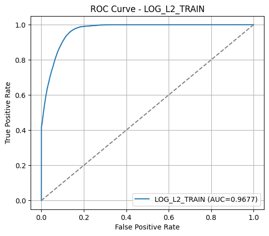

```
ROC-AUC (LOG_L2_TRAIN): 0.9677
```

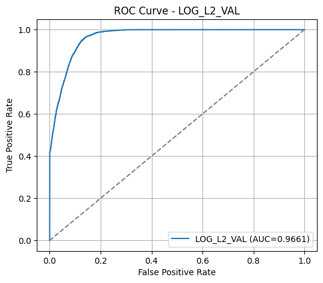

```
ROC-AUC (LOG_L2_VAL): 0.9661

====================== LOG_L2 RESULTS ======================

--- TRAIN ---
ROC-AUC: 0.9677
Recall:  0.9553
F1:      0.8090
```

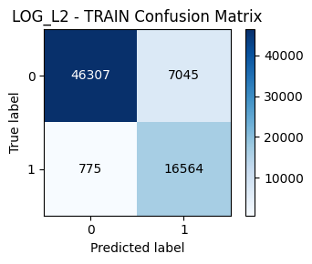

```
--- VAL ---
ROC-AUC: 0.9661
Recall:  0.9540
F1:      0.8084
```

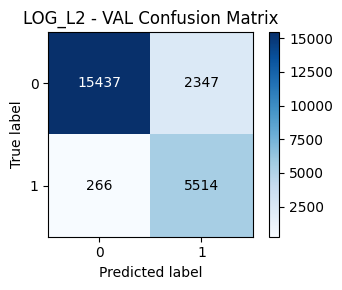

```python
# 1. Define CV
cv = StratifiedKFold(n_splits=5, shuffle=True, random_state=42)
# 2. Logistic Regression (L2) with class weights
log_base = LogisticRegression(
    class_weight=class_weights,
    max_iter=1000,
    solver="liblinear"      # supports L2
)

log_param_grid = {
    "C": [0.001, 0.01, 0.1, 1, 10],
    "penalty": ["l2"]
}

grid_log = GridSearchCV(
    estimator=log_base,
    param_grid=log_param_grid,
    scoring="f1",
    cv=cv,
    n_jobs=-1,
    verbose=1
)

# Fit on TRAIN ONLY (Xs_train, y_train_new)
grid_log.fit(Xs_train, y_train_new)

print("\n=== Logistic Regression (L2) CV results ===")
print("Best params:", grid_log.best_params_)
print("Best mean CV F1:", grid_log.best_score_)

# Best model
best_log = grid_log.best_estimator_

log_results = evaluate_model_full(
    model=best_log,
    X_train=Xs_train,
    y_train=y_train_new,
    X_val=Xs_val,
    y_val=y_val,
    model_name="LOG_L2"
)
```